# Lab 7: Facial Recognition

Lab 7 In-class Demo

Kristin Bennett

March 2021

# Overview

In Labs 6 and 7, we see that images represented by matrices can be converted to vectors and then analyzed using any of the analysis methods we have learned like PCA.

- We start with the 240 by 4096 training data matrix
- PCA/SVD produce an orthonormal basis $v_1,v_2,\ldots,v_{240}$. PCA only returns eigenvectors with nonzero eigenvalues.
- We can approximate the image a by projecting on the span of the first k eigenvectors
  $$proj_Sa=(a \cdot v_1)v_1+(a \cdot v_2)v_2+\cdots+(a \cdot v_k)v_k =aV_kV_k^T$$
  where $V_k$ columns are the first k basis vectors.

# Reconstructing a training image

Note scalarproj is only 240 dimensions

```r
tface<-52
# newface is the centered train face
newface<-trainface.centered[tface,]
# Get the scalar projections of newface.
scalarproj <- newface %*% my.pca$rotation
length(scalarproj)
```

```
## [1] 240
```

# Image Reconstruction

Now using just the 240 numbers in the scalar projection, we can reconstruct the image and compare it to the original image. Note we need to add back in the mean to get the original image.
$$scalarprojV^T+mean$$
.

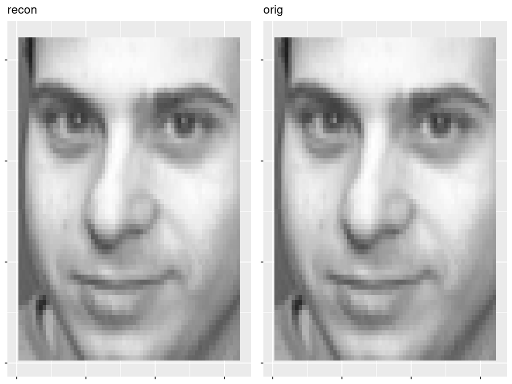

# Reconstruction Code - look for reconstruction and use of faceplot

```
recon<- t(my.pca$rotation)  # create the recon matrix as eigenvectors and then replace
pl <- scalarproj%*%t(my.pca$rotation)+train.mean
pl <- rbind(pl,trainface.uncentered[tface,])
faceplot(as.data.frame(pl),gcols=2,labels=c('recon','orig'))
```

# Recall mean face and first 5 eigenfaces

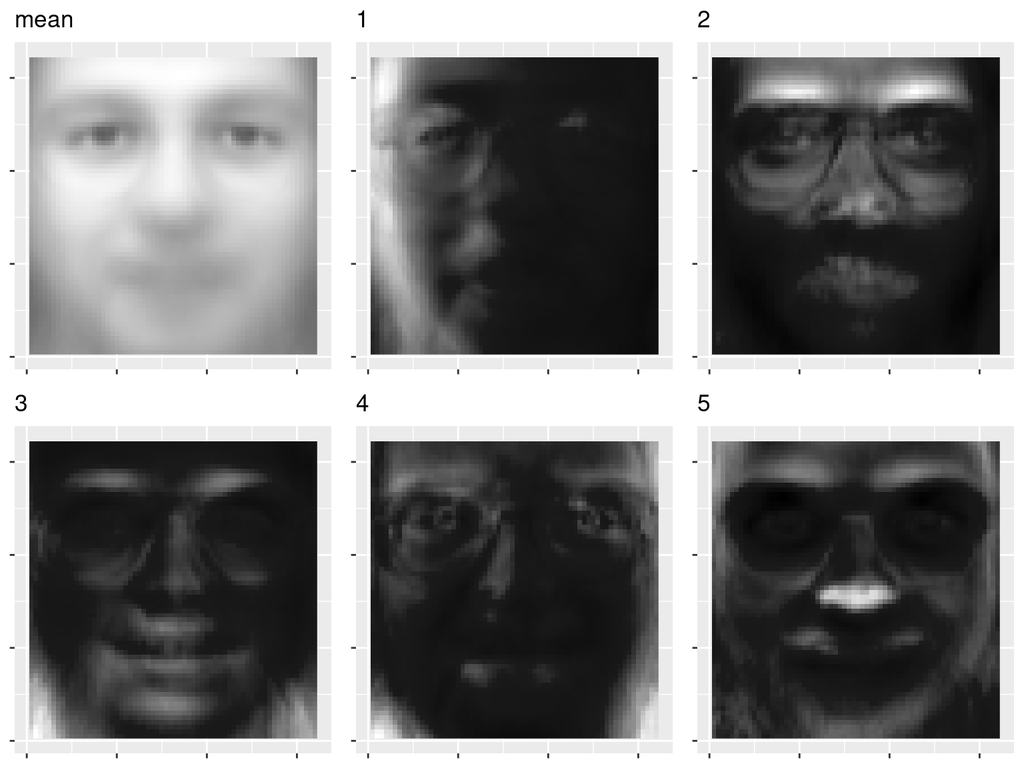

# Reconstruction with less eigenvectors

We can even try reconstructing with less variables. This code computes the reconstruction images using 1 eigenvector, 2 eigsvectors, and so on.

```r
# newface is the centered train face
newface<-trainface.centered[tface,]
# Get the scalar projections of newface.
scalarproj <- newface %*% my.pca$rotation
recon<- t(my.pca$rotation)  # create the recon matrix as eigenvectors and then replace with reconstructions
# n is the number of eigenvectors found.
n<-nrow(recon)
recon[1,] <- train.mean+scalarproj[1]*recon[1, ]  #Reconstruct uisng the first eigenvector
# Add s_i v_i to each row.
for(j in 2:n){
  recon[j, ] <- recon[j-1, ] +  scalarproj[j]*recon[j, ]}
```

# Mathematically what is in recon[j,] for j = 1 to n

# Reconstruction face

Reconstruction using only mean face and first five eigenvectors. The numbers are the scalar projections for that eigenvector.

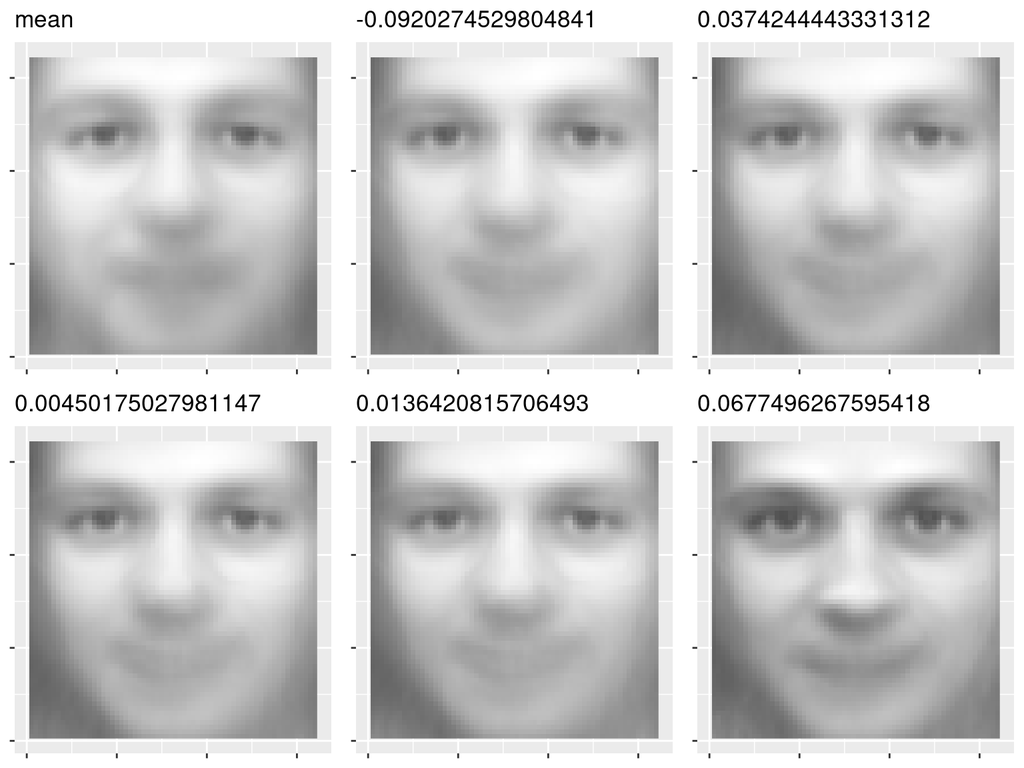

# Using more eigenvectors

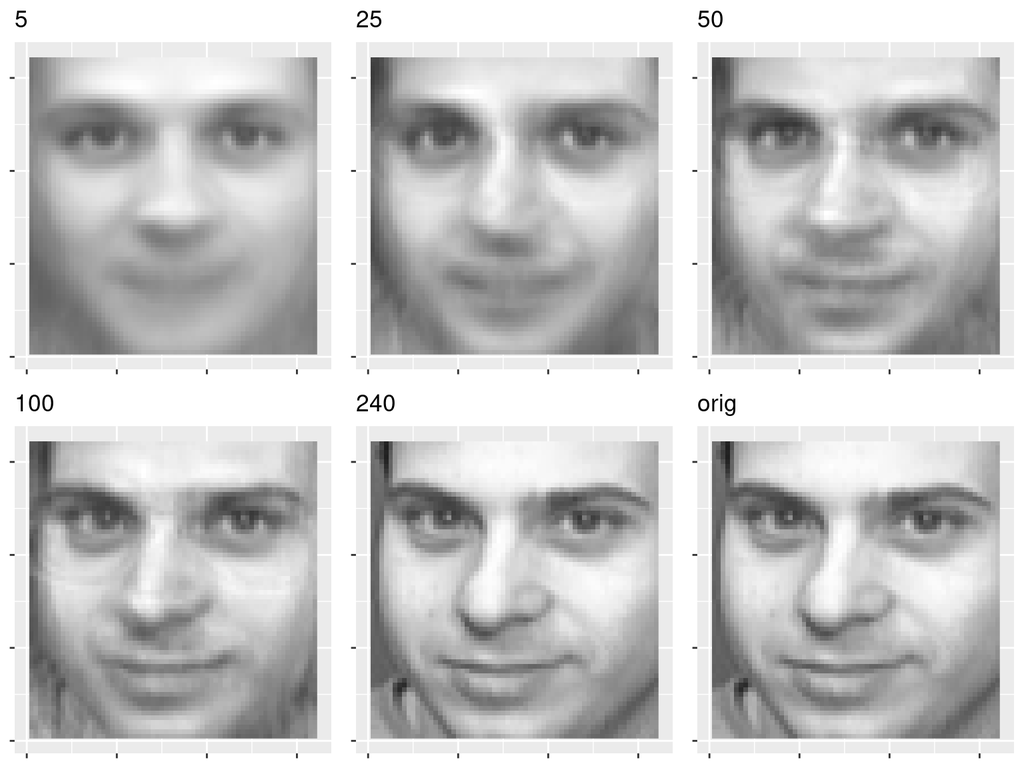

# Reconstructing a test face

Let’s try reconstructing test face 45. This one reconstructs very well.

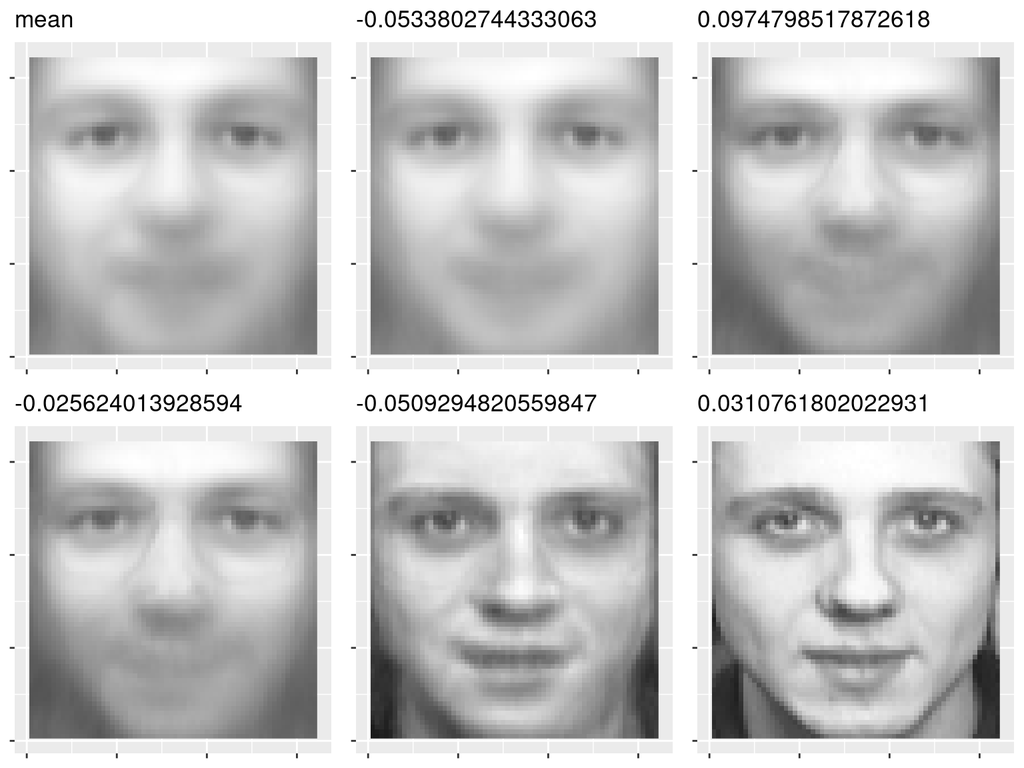

# Testing reconstruction code - how does it differ

```
tface<-45
# newface is the centered  test face
newface<-testface.uncentered[tface,]-train.mean
# Get the scalar projections of newface.
scalarproj <- newface %*% my.pca$rotation
recon<- t(my.pca$rotation)  # create the recon matrix as eigenvectors and then replace with reconstructions
# n is the number of eigenvectors found.
n<-nrow(recon)
recon[1,] <- train.mean+scalarproj[1]*recon[1, ]  #Reconstruct uisng the first eigenvector
# Add s_i v_i to each row.
for(j in 2:n){
  recon[j, ] <- recon[j-1, ] + scalarproj[j]*recon[j, ]}
# Plot selected reconstructions followed by the original image
pl <- rbind(train.mean,recon[c(1,2,3,45),])
pl <- rbind(pl,testface.uncentered[tface,])
faceplot(as.data.frame(pl),gcols=3,labels=c('mean',scalarproj[1:5]))
```

# Reconstructing test face 45

Using more eigenvectors.

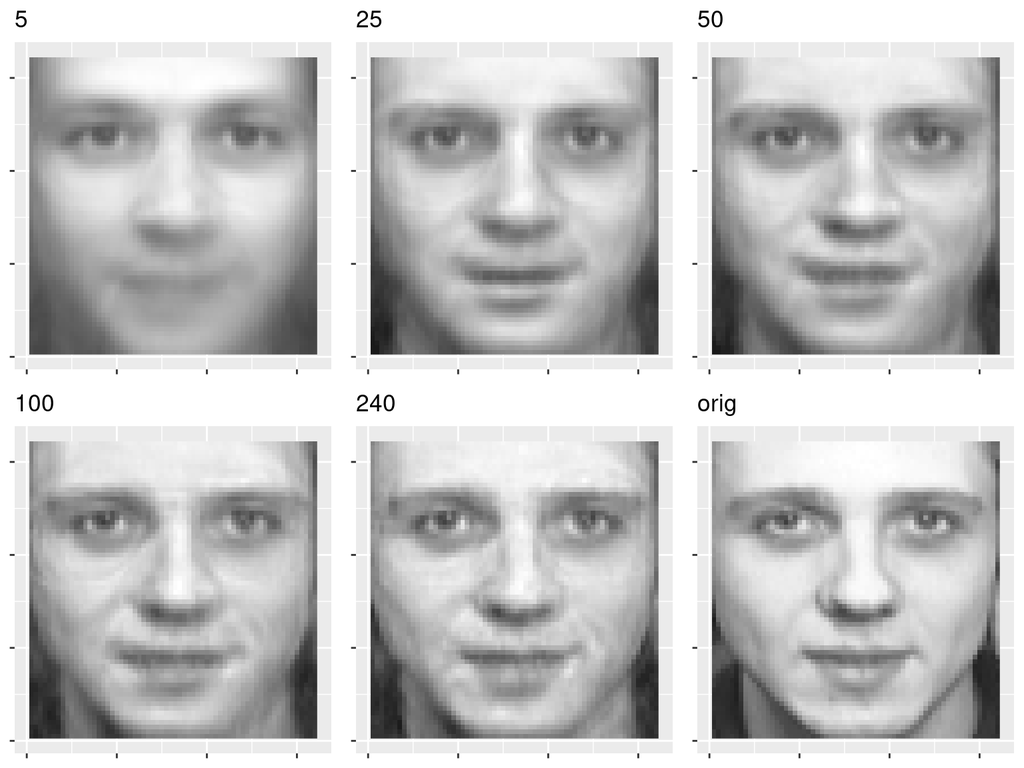

# Reconstructing another test face

Test image 31 is not reconstructed so well.

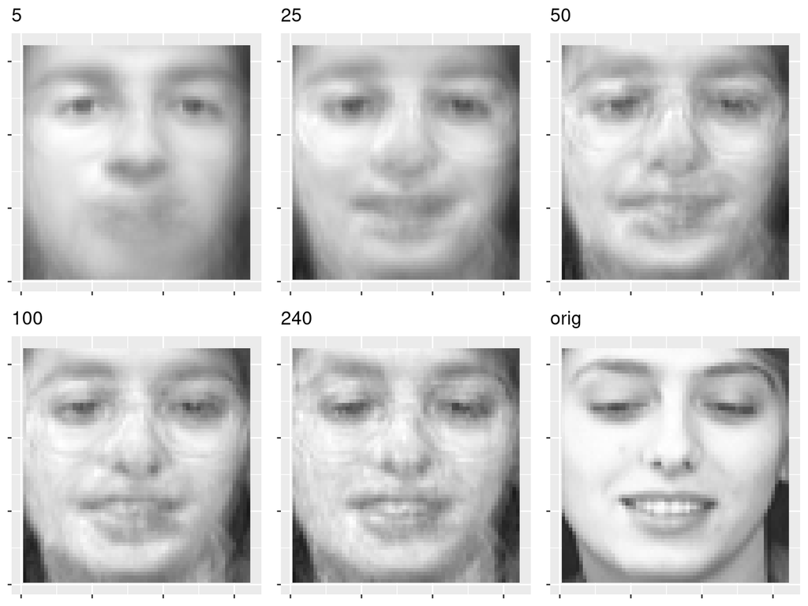

# Why?

Poor reconstruction results when the image is far from the space spanned by the eigenvectors. This is caused by the fact that there are few images of women in the datasets. A facial recognition system based on this bias dataset would tend to recognize men better than women. It would also do poorly on people with diverse skin tones.

# PCA summary

PCA linearly maps data to a lower dimensional space that preserves variance. Great for

- Data visualization
- Feature construction for other machine learning tasks (like classification)
- Data compression
- Data denoising

Still very widely used

# Beyond PCA - Deep learning is new state of the art

- Current facial recognition systems trained on massive databases are over 99% accurate and are much robust to rotations, lighting, hair, glasses, …
- They use “deep learning”
- Deep Learning increased power comes from a `nonlinear mapping`.
- Use a complex function that mimics how neurons in the human brain work.
- Can do all the things PCA can do
- but they are not readily interpretable like PCA.